# Integrating Novel Functional Annotations and Enrichment Methods for Gene Sets in NGS Analysis Workflows

Gordon David Mosher and Thomas Girke

# Introduction / Overview

### Our research focuses on combining existing tools

- systemPipeR - an end-to-end workflow tool for analyzing Next Generation Sequencing (NGS) data
- clusterProfiler - Gene Set Enrichment (GSE) statistical tests, charts and reports

### Our research goal

- Integrate clusterProfiler’s functional annotations and enrichment methods into systemPipeR
- using R-markdown to produce reproducible research

# Next Generation Sequencing produces an enormous amount of data for analysis.

### What is Next Generation Sequencing

- a massively parallel DNA/RNA sequencing technology
- an entire human genome can be sequenced within a single day
- LOW COST - makes analysis of individual samples feasible

### Analysis of Differentially Expressed Genes (DEGs) is practical

- when testing healthy vs. diseased tissue
- some genes are expressed more than others in one sample
- these are called Differentially Expressed Genes (DEGs)
- DEGs are an important input to the enrichment process

# The Problem

### Currently, the interpretation of gene function

- depends on analysis with new tools that are changing rapidly
- is made difficult by too many tools requiring computational expertise
- is laborious to adjust the data format for each step and to process all the steps
- there is a demand for easy to use workflows

# A Better Way

### A better way is to adopt a workflow that contains the best tools

- manages the data formats for each step
- processes each step automatically in a pipeline using param files
- systemPipeR
  - is easy to learn
  - is flexible
  - is faster
  - and gives better results!
- clusterProfiler
  - contains statistical tests
  - and functional annotation systems

# The Solution

### We integrate clusterProfiler’s functional annotations and enrichment methods into systemPipeR

- include the GSEA statistical test
- include the hypergeometric tests
- include a variety of functional annotation systems such as
  - Gene Ontology (GO)
  - pathways (KEGG)
  - Disease Ontology (DO)
  - and more
- The result: an end-to-end analysis ready for human interpretation

# Workflow Overview

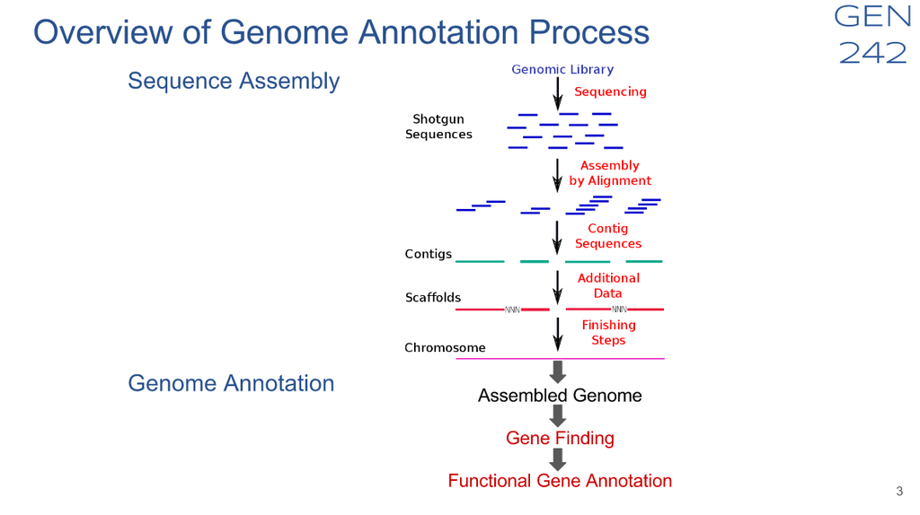

# systemPipeR

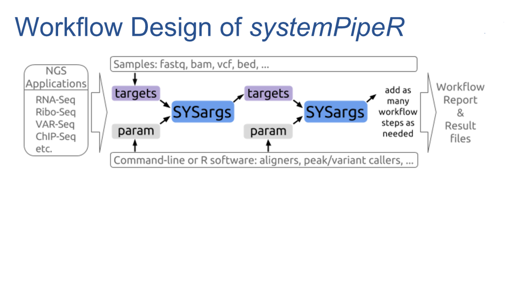

# Gene Set Enrichment (GSE) annotates the genes many ways.

- Using the Gene Ontology (GO) to annotate genes according to
  - MF is Molecular Function
  - BP is Biological Process
  - CC is Cellular Component
- There is also a Disease Ontology database that annotates according to disease terms.
- Enrichment uses the hypergeometric distribution function: $p = \sum_{k=x}^{n} \frac { {D \choose k}{N-D \choose n-k} }{N \choose n}$

# R Markdown by RStudio makes Reproducible Research

- This is an R Markdown presentation.
- For more details on using R Markdown see http://rmarkdown.rstudio.com.
- It’s free. You can learn the basics in a single afternoon on your own.

# Our Custom Code integrates the clusterProfiler enrichment process with the systemPipeR workflow.

```r
# my code
load(file="descv.RData")
de = names(descv)
if (length(de) == 100) {
    Cutoff = 1.0
} else {
    Cutoff = 0.55
}
Cutoff
ego = clusterProfiler::enrichGO(de, OrgDb = 'org.At.tair.db', keytype="TAIR", ont="MF",
                                pAdjustMethod = "BH", qvalueCutoff=Cutoff, pvalueCutoff=Cutoff)
ego@result[,c(1:7,9)]
ego2 = DOSE::setReadable(yyy, OrgDb = 'org.At.tair.db', keytype="TAIR")
str(ego2)
save(ego, file="ego.RData") # save for clusterProfiler visualization
```

- A sample call to an enrichment function demonstrates how input parameters are read from the disk, processed, and then written back to disk to be used later for graphing and reporting.
- End-users are not concerned with this level. Instead, they simply choose what steps to process.

# Our Results of the Enrichment Process

```r
# getwd()
if (substr(getwd(),nchar(getwd())-5,nchar(getwd())) != "rnaseq") {
  setwd("rnaseq")
}
load("ego.RData")
# ego@result[,c(1:7,9)]
ego@result[,c(2:3,5)]
```

```
                                         Description GeneRatio      pvalue
GO:0022804 active transmembrane transporter activity 468/20360 0.003635996
GO:0005198              structural molecule activity 454/20360 0.004309435
GO:0030554                 adenyl nucleotide binding 447/20360 0.004691367
GO:0032559             adenyl ribonucleotide binding 447/20360 0.004691367
GO:0005524                               ATP binding 441/20360 0.005045449
GO:0016887                           ATPase activity 423/20360 0.006275442
```

- A sample data frame, showing the results of the enrichment, demonstrates tabular data used for graphing, reporting, and interpretation. Data is easily imported and exported to Excel.
- Again, end-users simply choose which reports to prepare.

# Our Visualization of the Enrichment Results (ego)

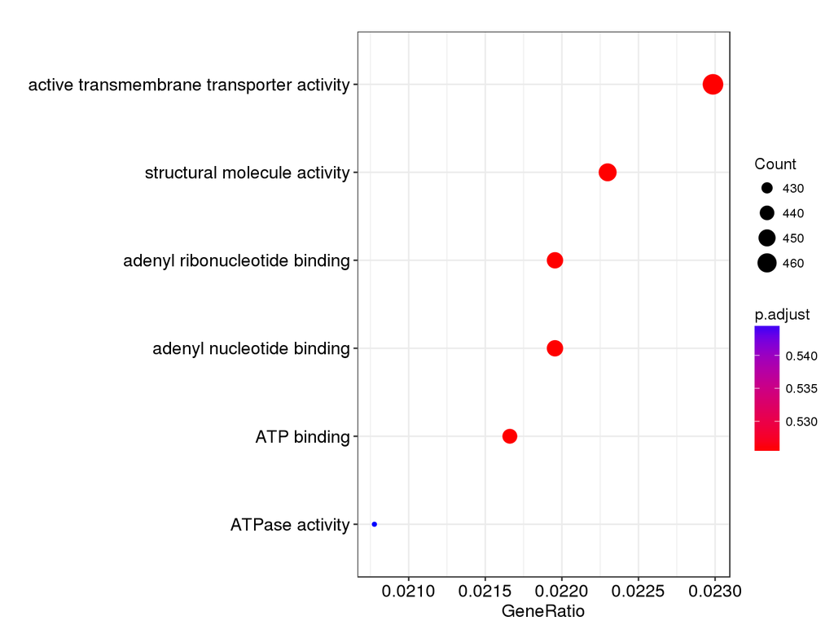

This graph shows the Gene Ratio plotted against the GO terms. The dot size represents the count of the genes in each term and the color depicts the significance.

The R language makes using four dimensional charts like this easy, and significantly increases the interpretability of the data.